# Plotting in R

MRC London Institute of Medical Sciences (LMS)  
https://lmsbioinformatics.github.io/LMS_PlottingInR/

### Materials.

All prerequisites, links to material and slides for this course can be found on github.

- [PlottingInR](https://lmsbioinformatics.github.io/LMS_PlottingInR/)

Or can be downloaded as a zip archive from here.

- [Download zip](https://github.com/LMSBioinformatics/LMS_PlottingInR/archive/master.zip)

### Materials. - Presentations, source code and practicals.

Once the zip file in unarchived. All presentations as HTML slides and pages, their R code and HTML practical sheets will be available in the directories underneath.

- **presentations/slides/** Presentations as an HTML slide show.
- **presentations/singlepage/** Presentations as an HTML single page.
- **presentations/rcode/** R code in presentations.
- **exercises/** Practicals as HTML pages.
- **answers/** Practicals with answers as HTML pages and R code solutions.

### Set the Working directory

Before running any of the code in the practicals or slides we need to set the working directory to the folder we unarchived.

**Session -> Set Working Directory -> Choose Directory**

or in the console.

```r
setwd("/PathToMyDownload/Reproducible-R")
# e.g. setwd("~/Downloads/Reproducible-R")
```

## Plotting in R

### Introduction

R has excellent graphics and plotting capabilities. They are mostly found in following three sources.

- base graphics

  easy to use, conceptually motivated by drawing on a canvas

  would become difficult or impossible to draw complicated plots
- the lattice package
- the ggplot2 package

  high-level approach: grammar of graphics
- saving your plots

Lattice and ggplot2 packages are built on grid graphics package while the base graphics routines adopt a pen and paper model for plotting.

We will start from the base graphics then focus on ggplot2

### Base Graphics

- Line Charts

First we'll produce a very simple graph using the values in the data.frame that we created:

```r
base_graph_df<- data.frame(sample_num=c(1:6),
                           treatment=c(0.02,1.8, 17.5, 55,75.7, 80),
                           control= c(0, 20, 40, 60, 80,100),
                           days=c("Mon","Tue","Wed","Thu","Fri","Sat"))

base_graph_df
```

```
  sample_num treatment control days
1          1      0.02       0  Mon
2          2      1.80      20  Tue
3          3     17.50      40  Wed
4          4     55.00      60  Thu
5          5     75.70      80  Fri
6          6     80.00     100  Sat
```

Plot the treatment with default parameters

```r
plot(base_graph_df$sample_num,base_graph_df$treatment)
```

### Line Plot

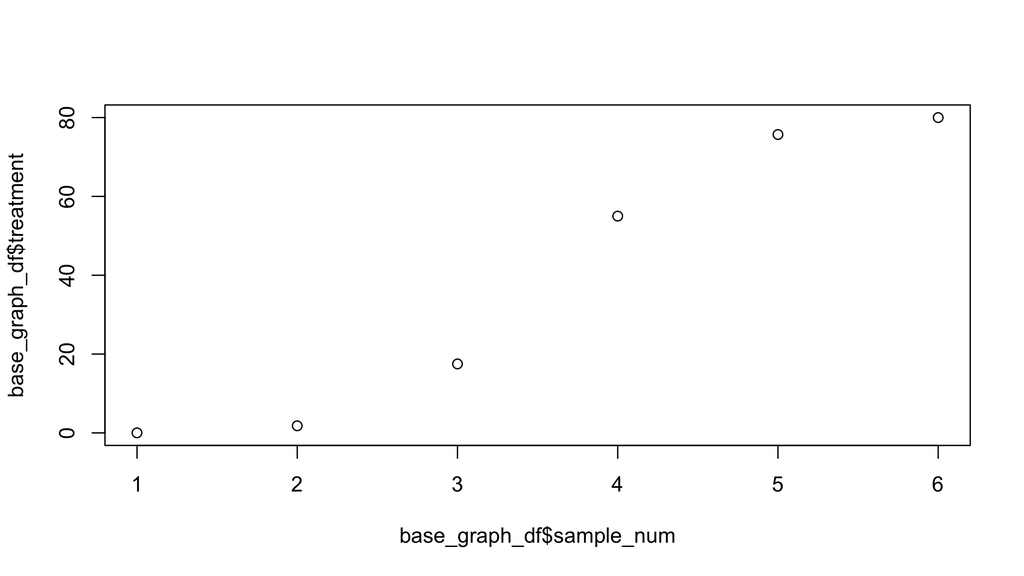

Now, let's add a title, a line to connect the points, and some color:

Plot treatment using blue points overlayed by a line

hint: look into the “type” argument

```r
?plot
```

```r
plot(base_graph_df$sample_num,base_graph_df$treatment, type="o", col="blue")
```

Create a title with a red, bold/italic font

```r
title(main="Treatment", col.main="red", font.main=4)
```

### Line Plot

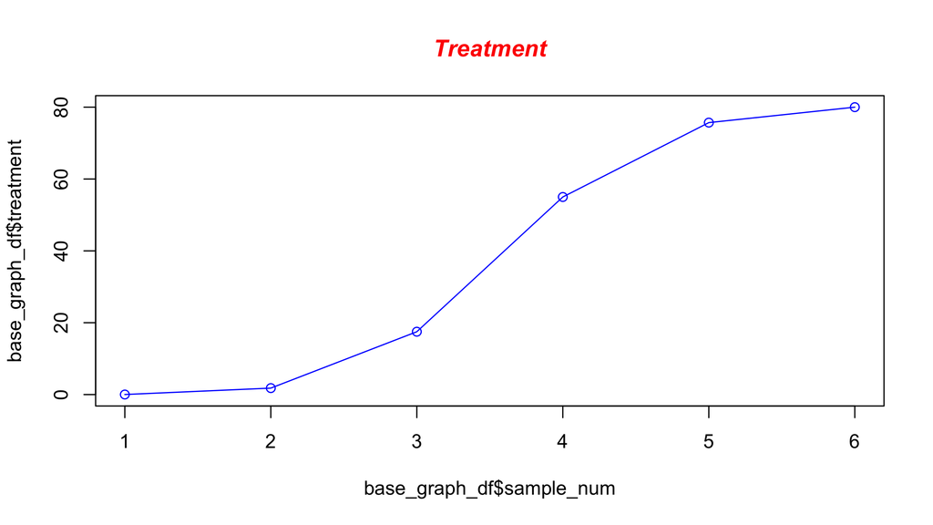

Now let's add a red line for a control vector and specify the y-axis range directly so it will be large enough to fit the data:

Define control vector

```r
base_graph_df$control
```

```
[1]   0  20  40  60  80 100
```

Plot treatment using a y axis that ranges from 0 to 100

```r
plot(base_graph_df$sample_num,base_graph_df$treatment, type="o", col="blue", ylim=c(0,100))
```

Plot control with red dashed line and square points

```r
lines(base_graph_df$control, type="o", pch=22, lty=2, col="red")
```

Create a title with a red, bold/italic font

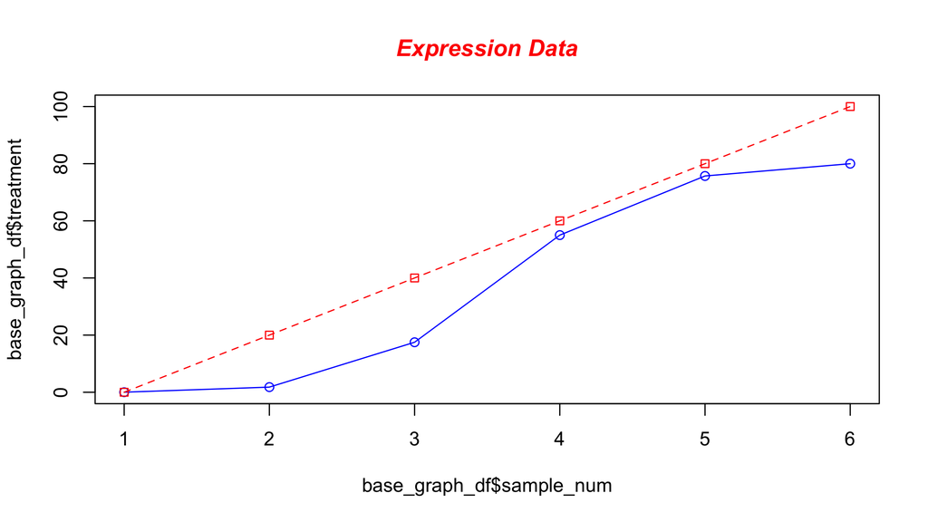

```r
title(main="Expression Data", col.main="red", font.main=4)
```

Next let's change the axes labels to match our data and add a legend. We'll also compute the y-axis values using the max function so any changes to our data will be automatically reflected in our graph.

Calculate range from 0 to max value of data

```r
g_range <- range(0, base_graph_df$treatment, base_graph_df$control)
g_range
```

```
[1]   0 100
```

range returns a vector containing the minimum and maximum of all the given arguments.

Plot treatment using y axis that ranges from 0 to max value in treatment or control vector. Turn off axes and annotations (axis labels) so we can specify them ourselves.

```r
plot(base_graph_df$sample_num ,base_graph_df$treatment, type="o", col="blue", ylim=g_range,
     axes=FALSE, ann=FALSE)
```

Make x axis using labels

```r
axis(1, at=1:6, lab=paste("Sample",c(1:6)))
```

Make y axis with horizontal labels that display ticks at every 20 marks.

```r
axis(2, las=1, at=20*0:g_range[2])
```

Create box around plot

```r
box()
```

Plot control vector with red dashed line and square points

```r
lines(base_graph_df$control, type="o", pch=22, lty=2, col="red")
```

Create a title with a red, bold/italic font

```r
title(main="Data", col.main="red", font.main=4)
```

Label the x and y axes with dark green text

```r
title(xlab="Samples", col.lab=rgb(0,0.5,0))
title(ylab="Values", col.lab=rgb(0,0.5,0))
```

Create a legend at (1, g_range[2]) that is slightly smaller (cex) and uses the same line colors and points used by the actual plots

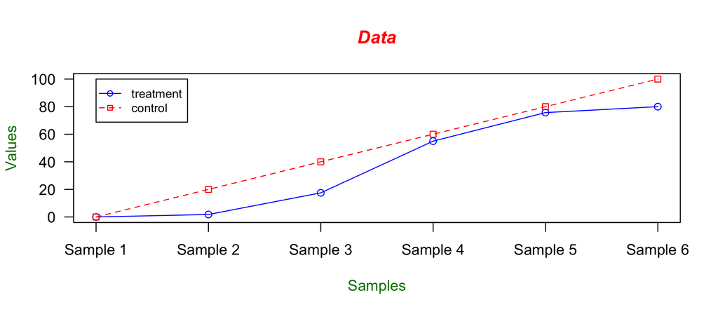

```r
legend(1, g_range[2], c("treatment","control"), cex=0.8, col=c("blue","red"), pch=21:22, lty=1:2);
```

### Bar Charts

Let's start with a simple bar chart graphing the treatment vector: Plot treatment

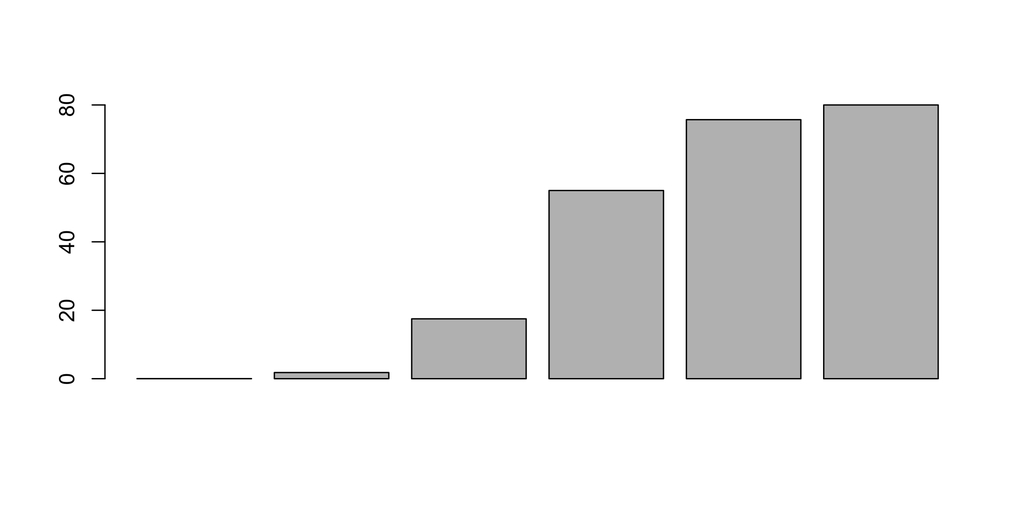

```r
barplot(base_graph_df$treatment)
```

Let's now read the data from the example.txt data file, add labels, blue borders around the bars, and density lines:

Read values from tab-delimited example.txt

```r
data <- read.table("data/example.txt", header=T, sep="\t")
```

Plot treatment with specified labels for axes. Use blue borders and diagonal lines in bars.

```r
barplot(data$treatment, main="Treatment", xlab="Days",ylab="values", names.arg=c("Mon","Tue","Wed","Thu","Fri","Sat"),
        border="blue", density=c(10,20,30,40,50,60))
```

names.arg is a vector of names to be plotted below each bar or group of bars. density a vector giving the density of shading lines, in lines per inch, for the bars or bar components.

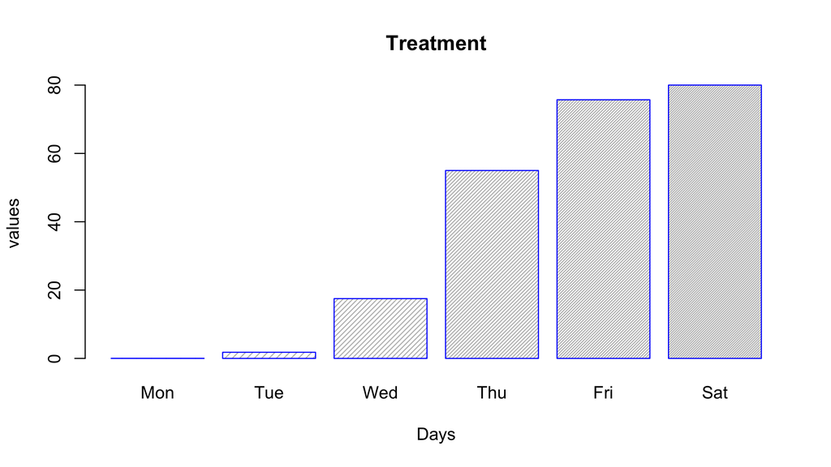

Now let's plot the treatment data using some color and show a legend:

Graph data with adjacent bars using colors

```r
barplot(as.matrix(data), main="Data", ylab= "Total", beside=TRUE, col= c("lightblue", "mistyrose", "lightcyan","lavender", "cornsilk","maroon"))
```

Place the legend at the top-left corner with no frame

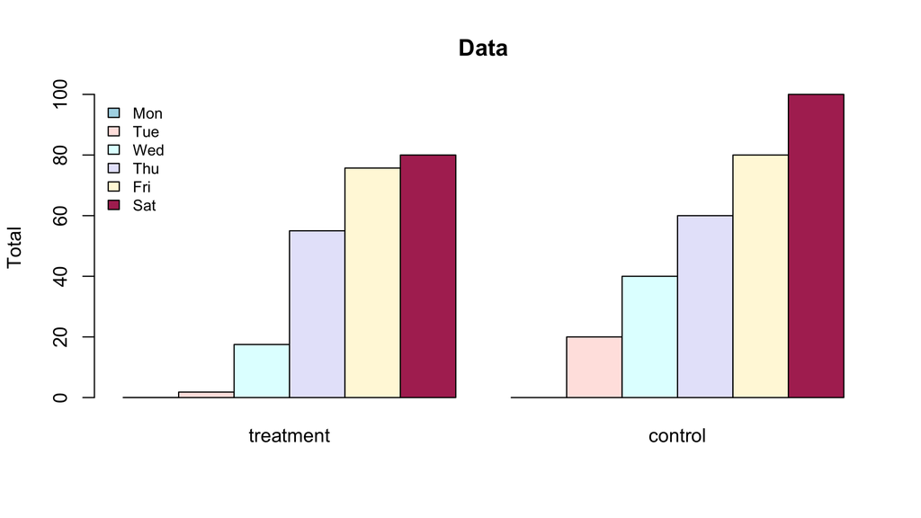

```r
legend("topleft", c("Mon","Tue","Wed","Thu","Fri","Sat"), cex=0.8,bty="n",
fill=  c("lightblue", "mistyrose", "lightcyan","lavender", "cornsilk","maroon"));
```

### Histograms

Create a histogram for treatment

```r
hist(treatment)
```

[output not shown]

```
Error in hist(treatment) : object 'treatment' not found
```